# Trabajo Extra

> [EDAED]

> Johann S. Cárdenas E - 1053852564

## libreria

```r
library(stringr)
library(data.table)
library(dplyr)
```

```r
library(tidyr)
library(ggplot2)
```

## lectura

```r
# leemos los datos como siempre
data_sad <- read.csv("data.csv", encoding = "UTF-8")
data_fine <- data_sad
```

## funcion

```r
# creamos una funcion para ahorrar algo de codigo
año <- function(my.string,expre){
  # mandamos la string y la expresion regular
  #mas info al respecto: https://rstudio-pubs-static.s3.amazonaws.com/74603_76cd14d5983f47408fdf0b323550b846.html
    p <- str_extract(my.string, expre)
    # reemplazamos todo por lo que retornemos en P
    str_replace_all(my.string, "Periodo_...._." , p)
}
```

## adecuacion

```r
# una belleza de librería
# hay que dar crédito; pero se modifica para adaptarla
# https://stackoverflow.com/questions/37756389/r-convert-multiple-columns-into-single-column
setDT(data_fine)
# con esto creamos solo dos columnas; en una de ellas el nombre de las columnas de periodo_xxxx_x y en otra los datos relacionados
data_nice<- melt(data_fine, measure.vars  = patterns("^Periodo"),
      value.name = c("DATOS"),
      variable.name = "PERIODO",
      variable.factor = FALSE,
      #elimina los NA
      na.rm = TRUE)
data_temp <- data_nice
```

## adecuacion tiempo

```r
  z <- data_temp$PERIODO
# en periodo esta lo que necesitamos; por eso tomamos el año y el periodo por aparte
  data_temp$AÑO <- as.integer(año(z,"20.."))
  data_temp$PERIODO <- as.integer(año(z,".$"))
  # los '-' se reemplazan por NA
  data_temp$DATOS <- as.integer(data_temp$DATOS)
```

## resumen1

```r
summary(data_temp)
```

```
##                                                        PROVEEDOR
##  COLOMBIA TELECOMUNICACIONES S.A. ESP                       :35802
##  EDATEL S.A. E.S.P.                                         : 9513
##  UNE EPM TELECOMUNICACIONES S.A. E.S.P. - UNE EPM TELCO S.A.: 6057
##  TELMEX COLOMBIA S.A.                                       : 5355
##  GILAT COLOMBIA S A ESP                                     : 4401
##  EMPRESA DE TELECOMUNICACIONES DE BOGOTÁ S.A. ESP.          : 1665
##  (Other)                                                    : 4032
##           DEPARTAMENTO          MUNICIPIO
##  ANTIOQUIA      : 9738   CALI        :  441
##  CUNDINAMARCA   : 7911   PALMIRA     :  396
##  VALLE DEL CAUCA: 5697   BOGOTÁ, D.C.:  378
##  SANTANDER      : 4428   POPAYÁN     :  360
##  BOYACÁ         : 3906   CARTAGO     :  351
##  CÓRDOBA        : 3213   ARMENIA     :  342
##  (Other)        :31932   (Other)     :64557
##                             SEGMENTO        PERIODO          DATOS
##  Corporativo                    :13752   Min.   :1.000   Min.   :     0
##  Residencial - Estrato 2        :10512   1st Qu.:2.000   1st Qu.:     4
##  Residencial - Estrato 1        :10143   Median :3.000   Median :    23
##  Residencial - Estrato 3        : 9738   Mean   :2.667   Mean   :  1119
##  Sin estratificar               : 6210   3rd Qu.:4.000   3rd Qu.:   196
##  Uso propio interno del operador: 6102   Max.   :4.000   Max.   :467515
##  (Other)                        :10368                   NA's   :10296
##       AÑO
##  Min.   :2015
##  1st Qu.:2016
##  Median :2016
##  Mean   :2016
##  3rd Qu.:2017
##  Max.   :2017
##
```

## borrando NA

```r
# eliminando nos NA y 0
data_mela <- data_temp %>%
          filter(!is.na(DATOS) & DATOS != 0) %>%
          droplevels()
```

## resumen2

```r
summary(data_mela)
```

```
##                                                        PROVEEDOR
##  COLOMBIA TELECOMUNICACIONES S.A. ESP                       :28845
##  EDATEL S.A. E.S.P.                                         : 8708
##  TELMEX COLOMBIA S.A.                                       : 4806
##  UNE EPM TELECOMUNICACIONES S.A. E.S.P. - UNE EPM TELCO S.A.: 4406
##  GILAT COLOMBIA S A ESP                                     : 1902
##  EMPRESA DE TELECOMUNICACIONES DE BOGOTÁ S.A. ESP.          : 1585
##  (Other)                                                    : 2565
##           DEPARTAMENTO          MUNICIPIO
##  ANTIOQUIA      : 8720   CALI        :  355
##  CUNDINAMARCA   : 6486   BOGOTÁ, D.C.:  328
##  VALLE DEL CAUCA: 3998   SINCELEJO   :  290
##  SANTANDER      : 3777   MONTERÍA    :  289
##  BOYACÁ         : 3013   ARMENIA     :  287
##  CÓRDOBA        : 2529   POPAYÁN     :  285
##  (Other)        :24294   (Other)     :50983
##                     SEGMENTO        PERIODO          DATOS
##  Corporativo            :11260   Min.   :1.000   Min.   :     1
##  Residencial - Estrato 2: 9621   1st Qu.:2.000   1st Qu.:     6
##  Residencial - Estrato 1: 8935   Median :3.000   Median :    29
##  Residencial - Estrato 3: 8672   Mean   :2.669   Mean   :  1197
##  Residencial - Estrato 4: 4361   3rd Qu.:4.000   3rd Qu.:   227
##  Sin estratificar       : 3560   Max.   :4.000   Max.   :467515
##  (Other)                : 6408
##       AÑO
##  Min.   :2015
##  1st Qu.:2016
##  Median :2016
##  Mean   :2016
##  3rd Qu.:2017
##  Max.   :2017
##
```

# 1.¿El número de líneas telefónicas fijas en Colombia están disminuyendo entre el 2015 y el 2017?

## resumen3

```r
resumen <- data_mela %>%
           group_by(AÑO) %>%
           summarise(promedio = mean(DATOS),
                     desvEst  = sd(DATOS),
                     sum = sum(DATOS))
resumen
```

```
## # A tibble: 3 x 4
##     AÑO promedio desvEst      sum
##   <int>    <dbl>   <dbl>    <int>
## 1  2015    1192.  10509.  7109254
## 2  2016    1199.  10404. 28393059
## 3  2017    1197.  10255. 27739177
```

La representación de los datos de telefonía en general para cada año; tieniendo en cuenta el promedio y la sumatoria de estos; ya que las tres cajas estan similiares, es dificíl identificar las diferencias.

## Datos de telefonía en general para cada año

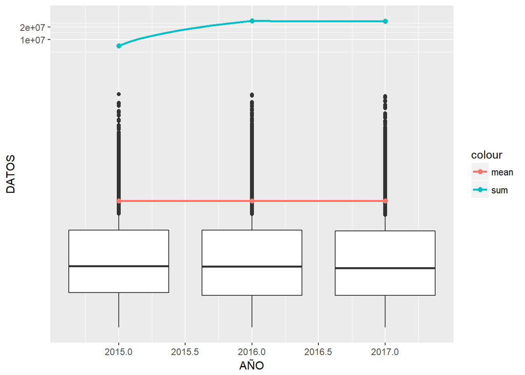

```r
boxe <- data_mela
  boxe <- boxe%>% select(AÑO, DATOS)
ggplot(boxe, aes(x=AÑO, y=DATOS, group=AÑO))+
    geom_boxplot()+
    stat_summary(fun.y = "mean",geom = "smooth",
                 aes(colour = "mean",group=1),
                 size = 1) + coord_trans(y="log10")+
    stat_summary(fun.y = "mean",geom = "point",
                 aes(colour = "mean",group=1),
                 size = 2) + coord_trans(y="log10")+

      stat_summary(fun.y = "sum",geom = "smooth",
                 aes(colour = "sum",group=1),
                 size = 1) + coord_trans(y="log10")+
      stat_summary(fun.y = "sum",geom = "point",
                 aes(colour = "sum",group=1),
                 size = 2) + coord_trans(y="log10")
```

# 2.¿-En qué casos están aumentando? (¿En cuáles departamentos y en qué estrato?)

En cuanto en estratos, contrario a lo que se pueda pensar; los estratos 2 y 3 estan estrechamente correlacionados en los resultados, los cuales son los mas altos según el estudio; por consiguiente el tercer lugar está reservado para el estrato 4, quien tiene una gran diferencia respescto a nuestros encabezados.

Ahora bien; para refutar lo anterior, se hizo lo siguiente:

## asigancion boxe2

```r
boxe2 <- data_mela
```

## Primer resumen; agrupado por segmentos.

```r
resumen1 <- data_mela %>%
           group_by(SEGMENTO) %>%
           summarise(promedio = mean(DATOS),
                     desvEst  = sd(DATOS),
                     sum = sum(DATOS))
resumen1
```

```
## # A tibble: 9 x 4
##   SEGMENTO                        promedio desvEst      sum
##   <fct>                              <dbl>   <dbl>    <int>
## 1 Corporativo                       1166.   13450. 13131728
## 2 Residencial - Estrato 1            537.    3263.  4800415
## 3 Residencial - Estrato 2           1951.   12317. 18775349
## 4 Residencial - Estrato 3           1852.   13874. 16057590
## 5 Residencial - Estrato 4           1443.    8187.  6294424
## 6 Residencial - Estrato 5           1096.    4934.  2202602
## 7 Residencial - Estrato 6            841.    4287.  1600257
## 8 Sin estratificar                    50.8    180.   180978
## 9 Uso propio interno del operador     79.4    540.   198147
```

Realizamos una gráfica en relación con los datos que se tienen y los departamentos; para lo cual se opta por hacer contraste con la media de estos datos, al tiempo en esta gráfica.

## Lineas Telefonícas Por Departamento

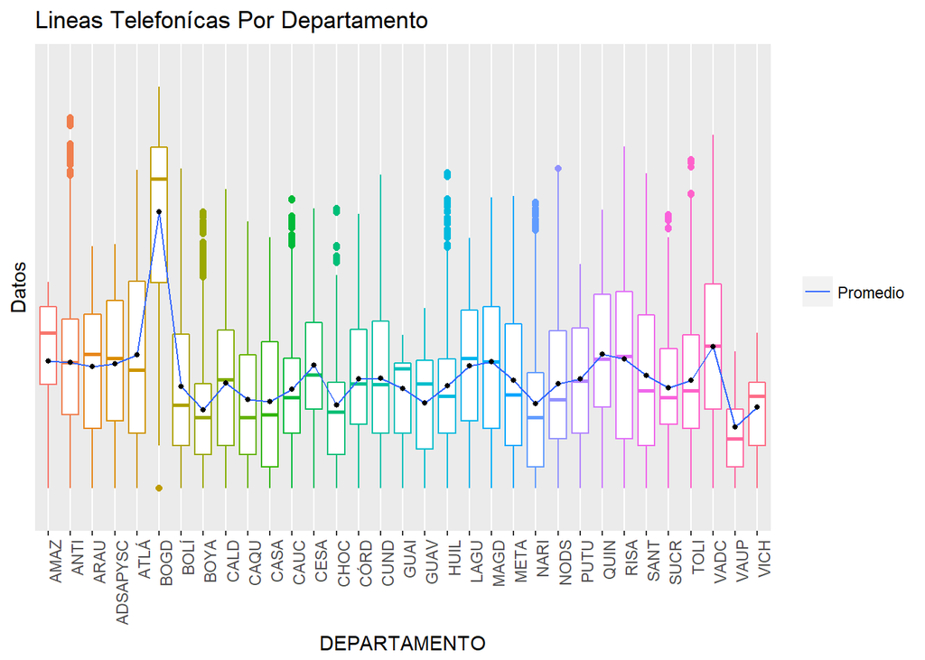

```r
# generamos la grafica; seleccionando lo útil
  boxe2 <- boxe2%>% select(DEPARTAMENTO, DATOS, SEGMENTO, AÑO)
ggplot(boxe2, aes(y=log10(DATOS), x=DEPARTAMENTO, group=DEPARTAMENTO, angle = 45))+
    geom_boxplot(aes(colour = DEPARTAMENTO))+
    scale_colour_discrete(guide=FALSE)+

    theme(axis.text.x = element_text(angle = 90, hjust = 1))+
    #se resumen los nombres; son muy largos
    scale_x_discrete(label=abbreviate)+
    scale_y_discrete(label=abbreviate)+
      stat_summary(fun.y = "mean",geom = "smooth",
                 aes(fill = "Promedio",group=1),
                 size = 0.5) +
        stat_summary(fun.y = "mean",geom = "point",
                 aes(group=1),
                 size = 1)+
  labs(title = "Lineas Telefonícas Por Departamento", y="Datos")+
  theme(legend.title=element_blank())
```

De acuerdo al gráfico, BOGOTÁ D.C. en general tiene las mayores concentraciones de datos; quizá por la facilidad que provee ETB (empresa de telecomunicaciones de bogotá) para tener un servicio de telefonía, pues historícamente es fundamental en el desarrollo de las telecomunicaciones en Colombia.

Para continuar con el estudio, se procede a filtrar datos, primariamente por estrato y de seguido, por departamento.

## boxe3

```r
boxe3 <- data_mela
# separamos los estratos que nos interesan
  boxe3 <- boxe3%>% select(DEPARTAMENTO, DATOS, SEGMENTO, AÑO)%>%
  filter(SEGMENTO %in% "Residencial - Estrato 2" |  SEGMENTO %in% "Residencial - Estrato 3" | SEGMENTO %in% "Residencial - Estrato 4")
```

## Un resumen de lo que se tiene.

```r
# un anlisis con lo que se tiene
resumen2 <- boxe3 %>%
           group_by(DEPARTAMENTO) %>%
           summarise(promedio = mean(DATOS),
                     desvEst  = sd(DATOS),
                     sum = sum(DATOS),
                     max = max(DATOS))
resumen2[order(-resumen2$promedio),]
```

```
## # A tibble: 33 x 5
##    DEPARTAMENTO       promedio desvEst      sum    max
##    <fct>                 <dbl>   <dbl>    <int>  <dbl>
##  1 BOGOTÁ D.C.         115987. 100818. 13106510 330153
##  2 VALLE DEL CAUCA       3129.  10138.  5105927  97441
##  3 ATLÁNTICO             2851.   6218.  1924182  30918
##  4 ANTIOQUIA             2360.  11903.  7961472 168254
##  5 RISARALDA             1735.   3253.   904163  17107
##  6 BOLÍVAR               1625.   4807.   815744  32761
##  7 MAGDALENA             1411.   2954.   444344  12672
##  8 SANTANDER             1385.   3969.  2372588  25972
##  9 NORTE DE SANTANDER    1078.   3669.   798832  32385
## 10 QUINDÍO               1032.   1739.   444675   7374
## # ... with 23 more rows
```

## Filtro por departamento.

```r
# separamos los deptos que nos interesan
  boxe3 <- boxe3%>% select(DEPARTAMENTO, DATOS, SEGMENTO, AÑO)%>%
  filter(DEPARTAMENTO %in% "BOGOTÁ D.C." |  DEPARTAMENTO %in% "VALLE DEL CAUCA" |DEPARTAMENTO %in% "ATLÁNTICO")
```

## Un nuevo resumen después de nuestro filtro; haciendo la agrupación por departamento.

```r
resumen3 <- boxe3 %>%
           group_by(DEPARTAMENTO) %>%
           summarise(promedio = mean(DATOS),
                     desvEst  = sd(DATOS),
                     sum = sum(DATOS),
                     max = max(DATOS))

resumen3
```

```
## # A tibble: 3 x 5
##   DEPARTAMENTO    promedio desvEst      sum    max
##   <fct>              <dbl>   <dbl>    <int>  <dbl>
## 1 ATLÁNTICO          2851.   6218.  1924182  30918
## 2 BOGOTÁ D.C.      115987. 100818. 13106510 330153
## 3 VALLE DEL CAUCA    3129.  10138.  5105927  97441
```

## Lo anteior, pero esta vez para segmento.

```r
resumen33 <- boxe3 %>%
           group_by(SEGMENTO) %>%
           summarise(promedio = mean(DATOS),
                     desvEst  = sd(DATOS),
                     sum = sum(DATOS),
                     max = max(DATOS))

resumen33
```

```
## # A tibble: 3 x 5
##   SEGMENTO                promedio desvEst     sum    max
##   <fct>                      <dbl>   <dbl>   <int>  <dbl>
## 1 Residencial - Estrato 2    9113.  34337. 8593406 288119
## 2 Residencial - Estrato 3    9152.  38918. 8254771 330153
## 3 Residencial - Estrato 4    5719.  19834. 3288442 124072
```

Teniendo esto, se puede dar paso al estudio en relación con el tiempo, para el caso peridóo 2015 a 2017; segmentado en tres partes. Tal cual se plantea se busca la relacion de los datos y los departamentos para los fragmentos de tiempo.

## Lineas Telefonícas Por Período

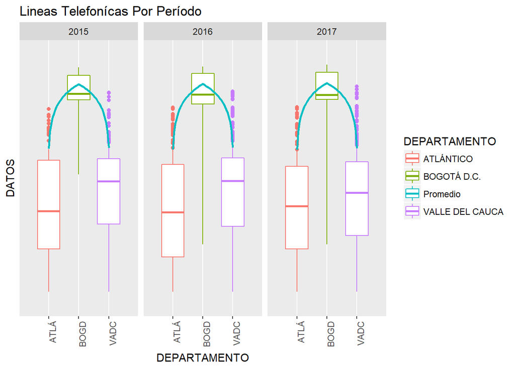

```r
ggplot(boxe3, aes(y=DATOS, x=DEPARTAMENTO, group=DEPARTAMENTO, angle = 45))+
    geom_boxplot(aes(colour = DEPARTAMENTO))+
    facet_wrap(~ AÑO, ncol = 3) +
    theme(axis.text.x = element_text(angle = 90, hjust = 1))+
    scale_x_discrete(label=abbreviate)+
    scale_y_discrete(label=abbreviate)+
      stat_summary(fun.y = "mean",geom = "smooth",
                 aes(colour = "Promedio",group=1),
                 size = 1) + coord_trans(y="log10")+
    labs(title = "Lineas Telefonícas Por Período")
```

Por el mismo orden de ideas, los fragmentos de tiempo, se reemplazan por los 3 estratos que previamente fueron seleccionados.

## Lineas Telefonícas por Segmento

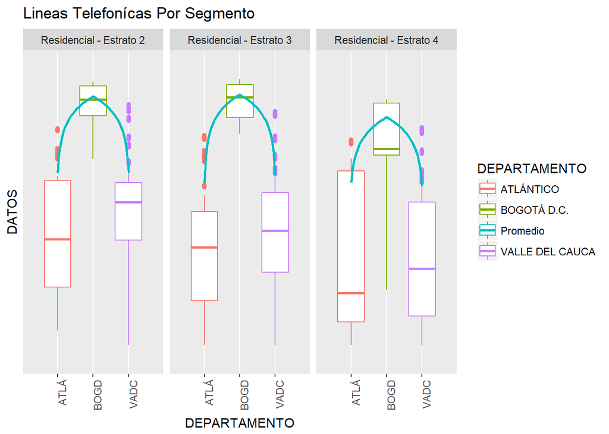

```r
ggplot(boxe3, aes(y=DATOS, x=DEPARTAMENTO, group=DEPARTAMENTO, angle = 45))+
    geom_boxplot(aes(colour = DEPARTAMENTO))+
    facet_wrap(~ SEGMENTO, ncol = 3) +
    theme(axis.text.x = element_text(angle = 90, hjust = 1))+
    scale_x_discrete(label=abbreviate)+
    scale_y_discrete(label=abbreviate)+
      stat_summary(fun.y = "mean",geom = "smooth",
                 aes(colour = "Promedio",group=1),
                 size = 1) + coord_trans(y="log10")+
    labs(title = "Lineas Telefonícas Por Segmento")
```

# Gráfica que se muestre por departamento el comportamiento del número de líneas telefónicas en el tiempo.

## asigancion boxe4

```r
boxe4 <- data_mela
```

Se hace un previo resumen para entender la gráfica mejor.

## resumen7

```r
resumen4 <- boxe4 %>%
           group_by(DEPARTAMENTO,AÑO) %>%
           summarise(promedio = mean(DATOS),
                     desvEst  = sd(DATOS),
                     sum = sum(DATOS),
                     max = max(DATOS))

resumen4[order(-resumen4$promedio),]
```

```
## # A tibble: 99 x 6
## # Groups:   DEPARTAMENTO [33]
##    DEPARTAMENTO      AÑO promedio desvEst     sum    max
##    <fct>           <int>    <dbl>   <dbl>   <int>  <dbl>
##  1 BOGOTÁ D.C.      2015   65198. 103545. 2347112 467515
##  2 BOGOTÁ D.C.      2016   64371. 100878. 9204990 457056
##  3 BOGOTÁ D.C.      2017   61528.  96455. 9167601 421316
##  4 ATLÁNTICO        2015    2101.   4965.  319368  27797
##  5 VALLE DEL CAUCA  2016    2001.   7268. 3594328  73695
##  6 ATLÁNTICO        2016    2001.   4892. 1304354  29926
##  7 VALLE DEL CAUCA  2015    1998.   7234.  883308  69570
##  8 ATLÁNTICO        2017    1878.   4777. 1335073  30918
##  9 VALLE DEL CAUCA  2017    1838.   7854. 3234096  97441
## 10 RISARALDA        2016    1585.   5721.  827320  66972
## # ... with 89 more rows
```

## Lineas Telefonícas Por Departamento En Tiempo

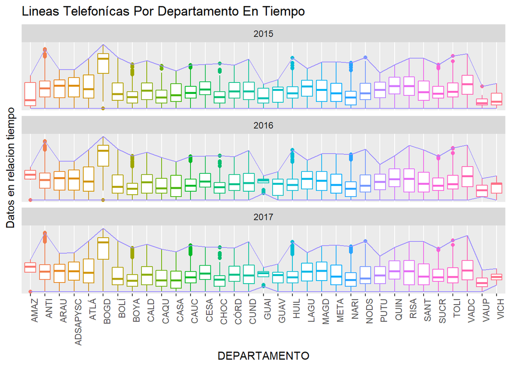

```r
# generamos la grafica; seleccionando lo útil
  boxe4 <- boxe4%>% select(DEPARTAMENTO, DATOS, AÑO)
ggplot(boxe4, aes(y=logb(DATOS,base=2), x=DEPARTAMENTO, group=DEPARTAMENTO, angle = 45))+
    geom_boxplot(aes(colour = DEPARTAMENTO))+
    scale_colour_discrete(guide=FALSE)+
    # theme(hjust = 1)+
     facet_wrap(~ AÑO, nrow  = 3) +
    # algo de estilos
    theme(axis.text.x = element_text(angle = 90, hjust = 1))+
    #se resumen los nombres; son muy largos
    scale_x_discrete(label=abbreviate)+
    scale_y_discrete(label=abbreviate)+
    stat_summary(fun.y = "max",geom = "smooth",
                 aes(colour = "Promedio",group=1),
                 size = 0.5) +
      stat_summary(fun.y = "min",geom = "smooth",
                 aes(colour = "Promedio",group=1),
                 size = 0.5)+
    labs(title = "Lineas Telefonícas Por Departamento En Tiempo", y="Datos en relacion tiempo")
```

# Gráfica que muestra el comportamiento del número de líneas en el tiempo por estrato.

## asignacion boxe5

```r
boxe5 <- data_mela
```

Se hace un previo resumen para entender la gráfica mejor.

## resumen 8

```r
resumen5 <- boxe5 %>%
           group_by(SEGMENTO,AÑO) %>%
           summarise(promedio = mean(DATOS),
                     desvEst  = sd(DATOS),
                     sum = sum(DATOS),
                     max = max(DATOS))

resumen5[order(-resumen5$promedio),]
```

```
## # A tibble: 27 x 6
## # Groups:   SEGMENTO [9]
##    SEGMENTO                  AÑO promedio desvEst     sum    max
##    <fct>                   <int>    <dbl>   <dbl>   <int>  <dbl>
##  1 Residencial - Estrato 2  2015    1968.  12496. 2147576 288119
##  2 Residencial - Estrato 2  2017    1956.  12303. 8230848 262124
##  3 Residencial - Estrato 2  2016    1942.  12288. 8396925 282395
##  4 Residencial - Estrato 3  2017    1880.  14219. 7112203 330153
##  5 Residencial - Estrato 3  2016    1837.  13648. 7163036 301872
##  6 Residencial - Estrato 3  2015    1802.  13427. 1782351 272254
##  7 Residencial - Estrato 4  2017    1504.   8439. 2857518 124072
##  8 Residencial - Estrato 4  2016    1401.   8009. 2756782 120360
##  9 Residencial - Estrato 4  2015    1380.   7913.  680124 112345
## 10 Corporativo              2016    1263.  14233. 6034955 457056
## # ... with 17 more rows
```

## grafica6

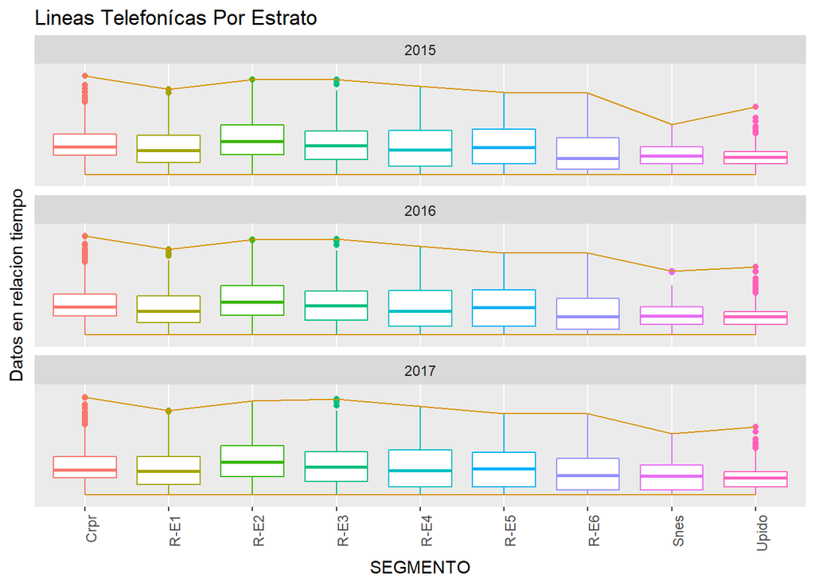

```r
# generamos la grafica; seleccionando lo útil
  boxe5 <- boxe5%>% select(SEGMENTO, DATOS, AÑO)
ggplot(boxe5, aes(y=logb(DATOS,base=14), x=SEGMENTO, group=SEGMENTO, angle = 45))+
    geom_boxplot(aes(colour = SEGMENTO))+
    scale_colour_discrete(guide=FALSE)+
    # theme(hjust = 1)+
     facet_wrap(~ AÑO, nrow  = 3) +
    # algo de estilos
    theme(axis.text.x = element_text(angle = 90, hjust = 1))+
    #se resumen los nombres; son muy largos
    scale_x_discrete(label=abbreviate)+
    scale_y_discrete(label=abbreviate)+
    stat_summary(fun.y = "max",geom = "smooth",
                 aes(colour = "Promedio",group=1),
                 size = 0.5) +
    stat_summary(fun.y = "min",geom = "smooth",
                 aes(colour = "Promedio",group=1),
                 size = 0.5)+  labs(title = "Lineas Telefonícas Por Estrato", y="Datos en relacion tiempo")
```

# Preguntas adicionales.

## asignacion boxe6

```r
boxe6 <- data_mela
```

## Agrupamos los datos de acuerdo al año

```r
box2015 <- boxe6 %>%
           group_by(MUNICIPIO,AÑO) %>%
           summarise(sumdos = sum(DATOS))%>%
  filter(AÑO %in% "2015")

# resumen 2016
box2016 <- boxe6 %>%
           group_by(MUNICIPIO,AÑO) %>%
           summarise(sumdos = sum(DATOS))%>%
  filter(AÑO %in% "2016")


# resumen 2017
box2017 <- boxe6 %>%
           group_by(MUNICIPIO,AÑO) %>%
           summarise(sumdos = sum(DATOS))%>%
  filter(AÑO %in% "2017")
```

## set null

```r
box15_16_17 <- NULL
box15_16<- NULL
```

## agrupación

```r
# similar a la calibración de celulares en el proyeco final se une lo obtendio anteriormente
box_15_16 <- box2015 %>%
          select(MUNICIPIO, AÑO, sumdos)%>%
           inner_join(select(box2016,MUNICIPIO, AÑO, sumdos),
                      by = "MUNICIPIO")
box15_16_17 <- box_15_16 %>%
           inner_join(select(box2017,MUNICIPIO, AÑO, sumdos),
                      by = "MUNICIPIO")
box15_16_17 <- as.data.frame(box15_16_17)
```

## agrupación.2

```r
data_deptxy <- box15_16_17 %>%
            filter(sumdos.x > sumdos.y)
  data_deptxy$dif <- data_deptxy$sumdos.y - data_deptxy$sumdos
  data_deptxy
```

```
##   MUNICIPIO AÑO.x sumdos.x AÑO.y sumdos.y  AÑO sumdos dif
## 1 ARBOLEDAS  2015       45  2016       33 2017      8  25
## 2 CUCUTILLA  2015       25  2016       15 2017      4  11
```

Al saber esto podemos proceder para verificar qué municipios han decadido en datos para el periodo de 2016-2017.

## resumen9

```r
data_deptys <- box15_16_17 %>%
            filter(sumdos.y > sumdos)
  data_deptys$dif <- data_deptys$sumdos.y - data_deptys$sumdos
  arrange(data_deptys, desc(dif))
```

```
##                       MUNICIPIO AÑO.x sumdos.x AÑO.y sumdos.y  AÑO  sumdos
## 1                       PALMIRA  2015    86116  2016   354533 2017  153646
## 2                       PEREIRA  2015   117937  2016   583419 2017  443353
## 3                      GIRARDOT  2015    30164  2016   121442 2017   37098
## 4                      MEDELLÍN  2015   793530  2016  3167733 2017 3095844
## 5           GUADALAJARA DE BUGA  2015    30653  2016   124208 2017   53146
## 6                       CARTAGO  2015    29483  2016   116419 2017   57811
## 7                  BOGOTÁ, D.C.  2015  2347112  2016  9204990 2017 9167601
## 8                  DOSQUEBRADAS  2015    42256  2016   188531 2017  161585
## 9                       FLANDES  2015     4540  2016    21845 2017    2915
## 10                   CANDELARIA  2015     8889  2016    37240 2017   20909
## 11                       IBAGUÉ  2015   117304  2016   459790 2017  444437
## 12                        YUMBO  2015    23939  2016    93986 2017   84984
## 13                       CÚCUTA  2015    97661  2016   379767 2017  370873
## 14                        NEIVA  2015    77509  2016   306214 2017  299422
```

[output cut: 1501 more lines]

# ¿En qué combinación de estrato y municipio se presenta un mayor aumento?

## merge2

```r
box2015ed <- boxe6 %>%
           group_by(MUNICIPIO,AÑO,SEGMENTO) %>%
           summarise(sumdos = sum(DATOS))%>%
  filter(AÑO %in% "2015")


# resumen 2016
box2016ed <- boxe6 %>%
           group_by(MUNICIPIO,AÑO,SEGMENTO) %>%
           summarise(sumdos = sum(DATOS))%>%
  filter(AÑO %in% "2016")


# resumen 2017
box2017ed <- boxe6 %>%
           group_by(MUNICIPIO,AÑO,SEGMENTO) %>%
           summarise(sumdos = sum(DATOS))%>%
  filter(AÑO %in% "2017")
```

## as data frame

```r
box2015ed <- as.data.frame(group_by(box2015ed, SEGMENTO))
box2016ed <- as.data.frame(group_by(box2016ed, SEGMENTO))
box2017ed <- as.data.frame(group_by(box2017ed, SEGMENTO))
```

## merge 3

```r
# similar al de la calibración, pero para el caso se debe usar otra función, la anterior no sirvió
box_15_16ed <- NULL
box_15_16ed <- merge(box2015ed, box2016ed, all = TRUE, by = "row.names")
box_15_16_17ed <- merge(box_15_16ed, box2017ed, all = TRUE, by = "row.names")
```

## borrar repetidos

```r
# se elimina la redundancia de datos
box_15_16_17ed$Row.names <-NULL
box_15_16_17ed$Row.names <-NULL
```

Se comparan las sumatorias de datos del periodo 2015 - 2016; y se calcula la diferencia, lo cual resulta en cuantos datos aumento para el periodo.

## resumen11

```r
data_deptestra <- box_15_16_17ed %>%
            filter(sumdos.x <  sumdos.y)
  d1516 <- data_deptestra$sumdos.y - data_deptestra$sumdos.x
  data_deptestra$dif_15_16 <- d1516
```

Se purga los datos, para darle un mejor orden y coherencia, ademas se tiene la diferencia para 2015 - 2016; 2016 - 2017 y los tres periodos correspondientes, así teniendo un estimado de mayor diferencia lo cual denota una mayor tasa de crecimiento en el lapso temporal.

sumdos: representa el total de datos.

dif_15_16: diferencia 2015-2016.

dif_16_17: diferencia 2016-2017.

dif_15_16_17: suma de diferencias.

## resumen12

```r
data_deptestra <- data_deptestra %>%
            filter(sumdos.y <  sumdos)
  d1617 <- data_deptestra$sumdos - data_deptestra$sumdos.y
  data_deptestra$dif_16_17 <- d1617
  data_deptestra$dif_15_16_17 <- d1617 + data_deptestra$dif_15_16
  data_deptestra <- data_deptestra[, -c(1:8)]
  data_deptestra$AÑO <- NULL
  arrange(data_deptestra, desc(dif_15_16_17))
```

```
##                        MUNICIPIO                        SEGMENTO sumdos
## 1                       MEDELLÍN         Residencial - Estrato 3 792954
## 2                       MEDELLÍN                     Corporativo 673156
## 3                           CALI         Residencial - Estrato 2 643986
## 4                   BOGOTÁ, D.C.         Residencial - Estrato 1 387890
## 5                       MEDELLÍN         Residencial - Estrato 4 367962
## 6                           CALI                     Corporativo 350582
## 7                   BOGOTÁ, D.C.         Residencial - Estrato 6 291881
## 8                           CALI         Residencial - Estrato 4 286880
## 9                           CALI         Residencial - Estrato 1 274109
## 10                  BARRANQUILLA         Residencial - Estrato 3 237989
## 11                      MEDELLÍN         Residencial - Estrato 5 225627
## 12                  BARRANQUILLA         Residencial - Estrato 2 208868
## 13                     CARTAGENA         Residencial - Estrato 2 199631
## 14                       SOLEDAD         Residencial - Estrato 2 198164
```

[output cut: 2093 more lines]

Gráficas adicionales. Gráfica que muestre los cinco (5) municipios que mayor aumento presente en número de líneas.

## Procedemos a tomar los datos.

```r
data_mun<- box15_16_17 %>%
            filter(sumdos.x <  sumdos.y &sumdos.y <  sumdos)
  d <- data_mun$sumdos.y - data_mun$sumdos.x
  data_mun$dif_15_16_17 <- d
  # data_mun <- data_mun[c(1, 5),]
  data_mun <- arrange(data_mun, desc(dif_15_16_17))
  cincomun <- data_mun[c(1:5),]
  cincomun
```

```
##      MUNICIPIO AÑO.x sumdos.x AÑO.y sumdos.y  AÑO  sumdos dif_15_16_17
## 1         CALI  2015   589083  2016  2404400 2017 2415585      1815317
## 2 BARRANQUILLA  2015   232981  2016   951587 2017  956327       718606
## 3  BUCARAMANGA  2015   176318  2016   726788 2017  780131       550470
## 4    CARTAGENA  2015   132087  2016   543450 2017  560941       411363
## 5       SOACHA  2015    93257  2016   382336 2017  395014       289079
```

## Aumento De Lineas Por Municipio

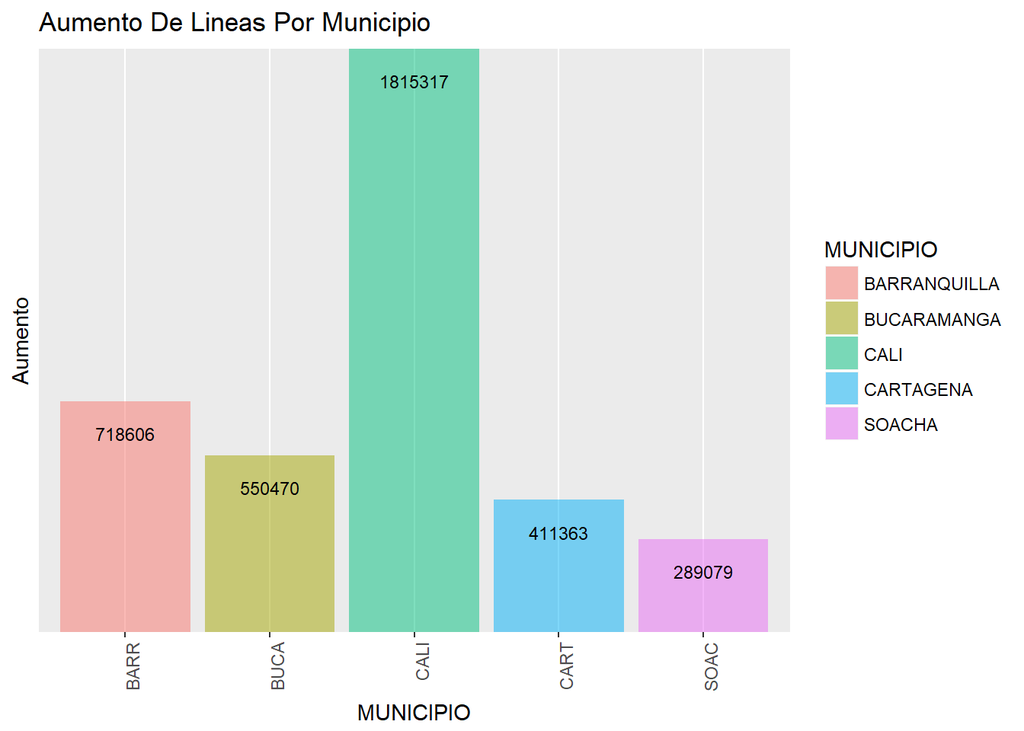

```r
ggplot(cincomun, aes(MUNICIPIO,dif_15_16_17,group=(MUNICIPIO)))+
    geom_histogram(aes(fill =MUNICIPIO), stat = "identity",alpha = 0.5)+
  geom_text(aes(label = dif_15_16_17, y = dif_15_16_17-100000), size = 3)+
  # theme(legend.position = "bottom") +
  labs(title = "Aumento De Lineas Por Municipio", y="Aumento")+
    theme(axis.text.x = element_text(angle = 90, hjust = 1))+
    scale_x_discrete(label=abbreviate)+
    scale_y_discrete(label=abbreviate)
```

Para este caso debemos hacer una modificaciones en los datos que tenianmos agrupado anteriormente.

## resumen14

```r
data_deptestramin <- box_15_16_17ed %>%
            filter(sumdos.x >  sumdos.y)
  d1516 <- data_deptestramin$sumdos.x - data_deptestramin$sumdos.y
  data_deptestramin$dif_15_16 <- d1516
```

## Ahora bien, recortamos y adecuamos los datos que se piden.

```r
data_deptestramin <- data_deptestramin %>%
            filter(sumdos.y  > sumdos)
  d1617 <- data_deptestramin$sumdos.y - data_deptestramin$sumdos
  data_deptestramin$dif_16_17 <- d1617
  data_deptestramin$dif_15_16_17 <- d1617 + data_deptestramin$dif_15_16
   data_deptestramin <- data_deptestramin[, -c(1:8)]
  data_deptestramin$AÑO <- NULL
  data_deptestramin <- data_deptestramin[, -c(3:5)]
  cincomin <- arrange(data_deptestramin, desc(dif_15_16_17))
    cincomin <- cincomin[c(1:5),]

  cincomin
```

```
##    MUNICIPIO                SEGMENTO dif_15_16_17
## 1     TÁMARA Residencial - Estrato 1       582194
## 2 FACATATIVÁ Residencial - Estrato 4       195599
## 3   TRINIDAD        Sin estratificar       151580
## 4   TRINIDAD             Corporativo       107297
## 5 FACATATIVÁ Residencial - Estrato 6        84840
```

## Disminución De Lineas Por Estrato

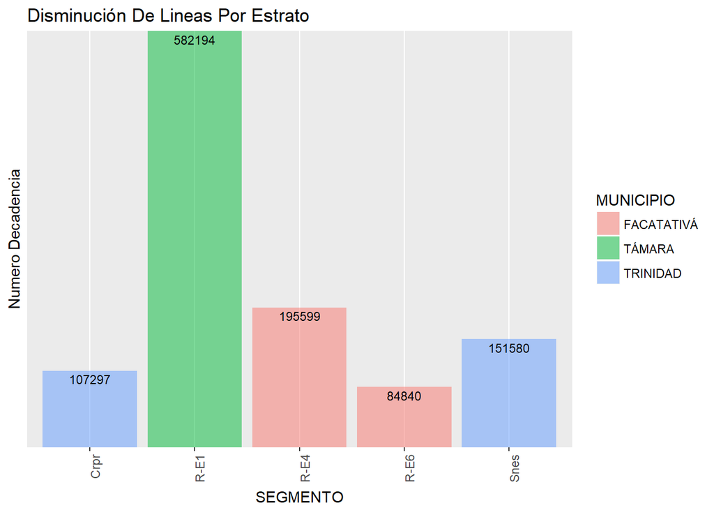

```r
ggplot(cincomin, aes(SEGMENTO,(dif_15_16_17),group=(MUNICIPIO)))+
    geom_histogram(aes(fill =MUNICIPIO), stat="identity",alpha = 0.5)+
  geom_text(aes(label = dif_15_16_17, y = dif_15_16_17-11800), size = 3)+
   # facet_wrap(~ MUNICIPIO, ncol   = 3) +
  labs(title = "Disminución De Lineas Por Estrato", y="Numero Decadencia")+
    theme(axis.text.x = element_text(angle = 90, hjust = 1))+
    scale_x_discrete(label=abbreviate)+
    scale_y_discrete(label=abbreviate)
```